# Other Questions

John Cornelison

2024-03-11

## General Summary

#### Q6 Intakes, Live Release Rate

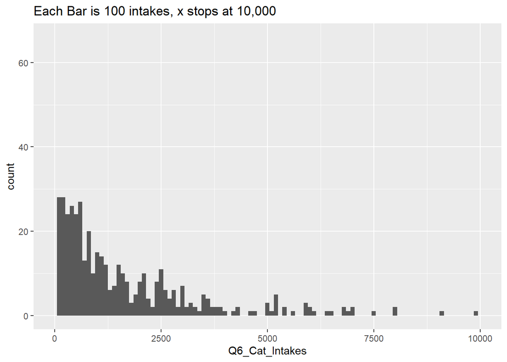

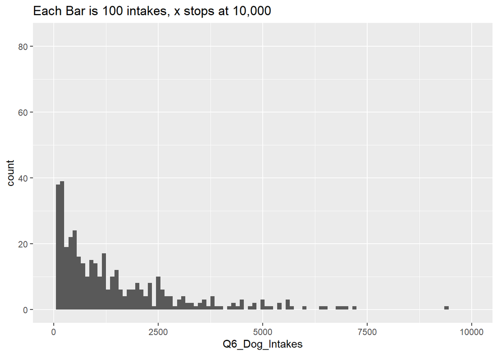

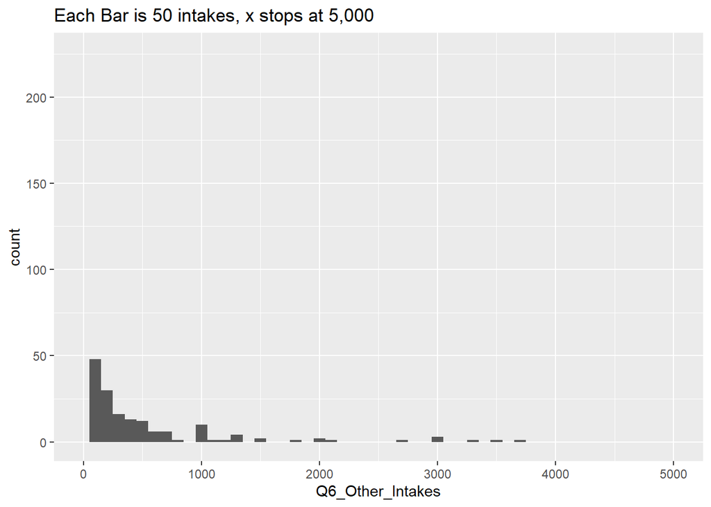

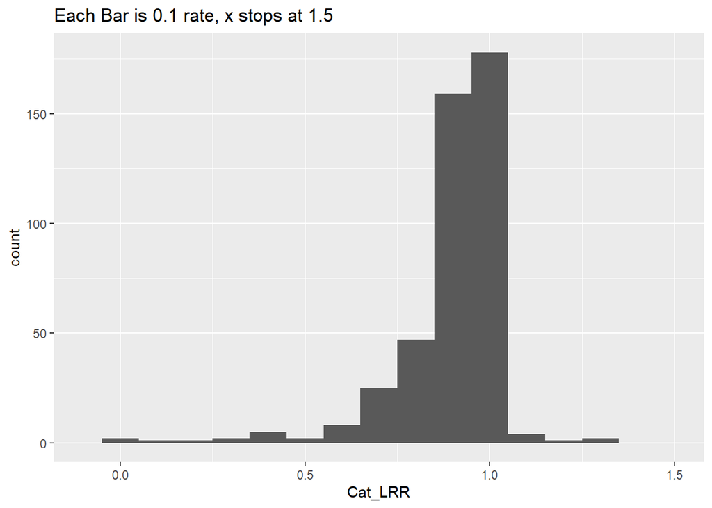

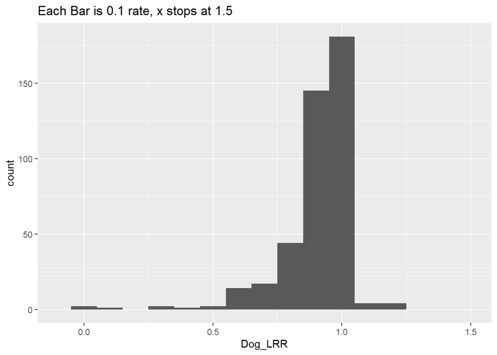

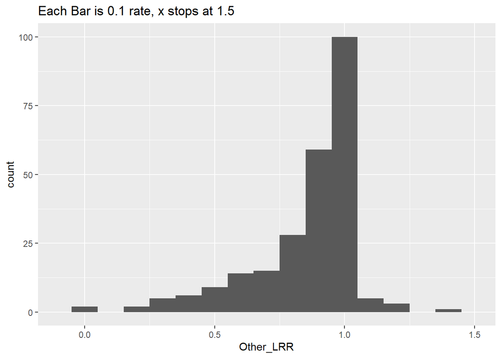

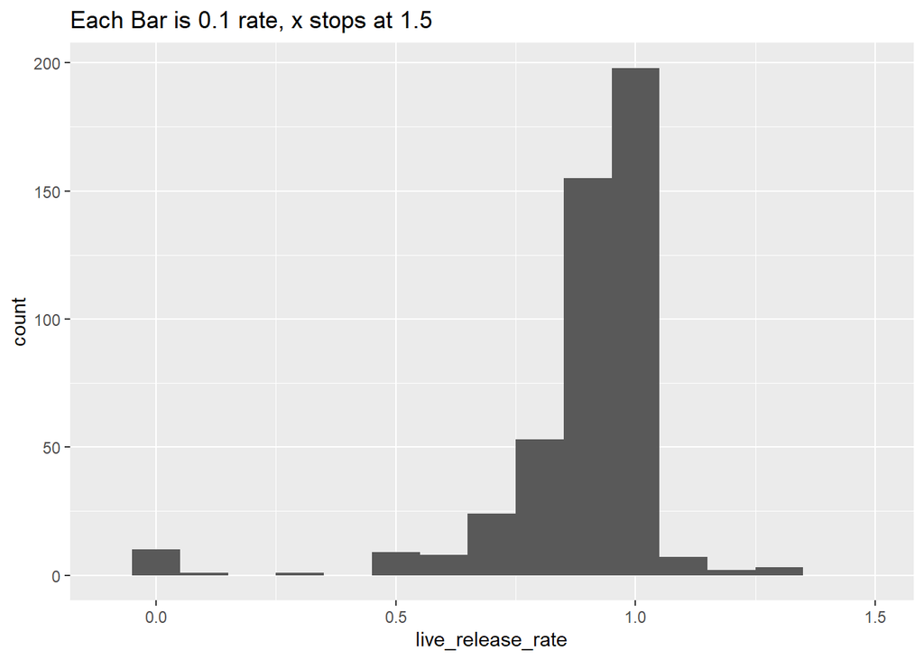

#### Q7 Average Length of Stay

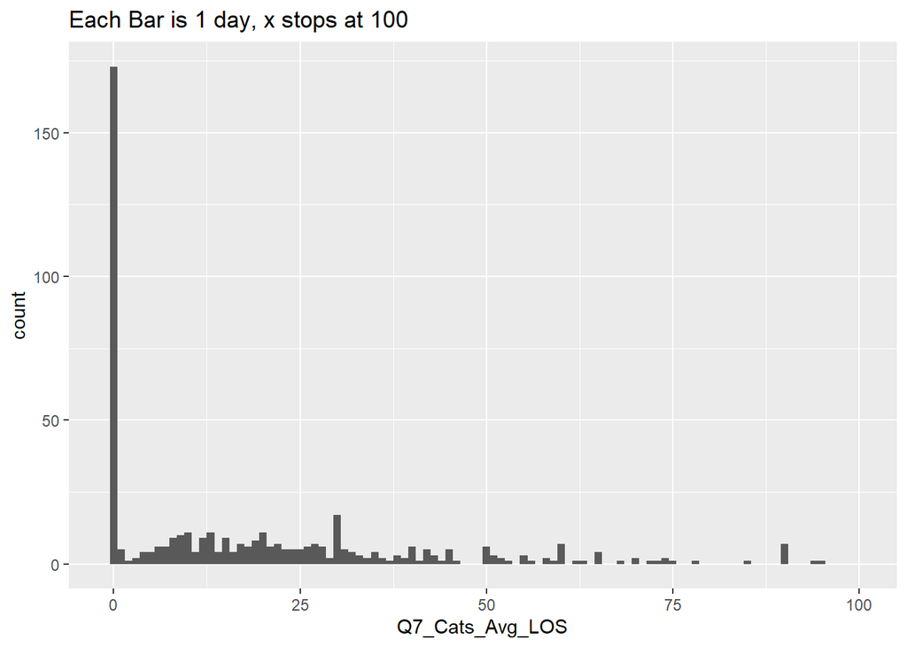

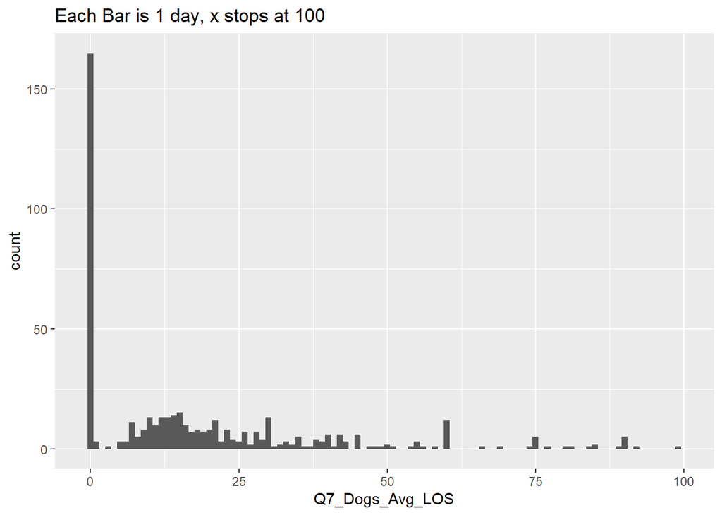

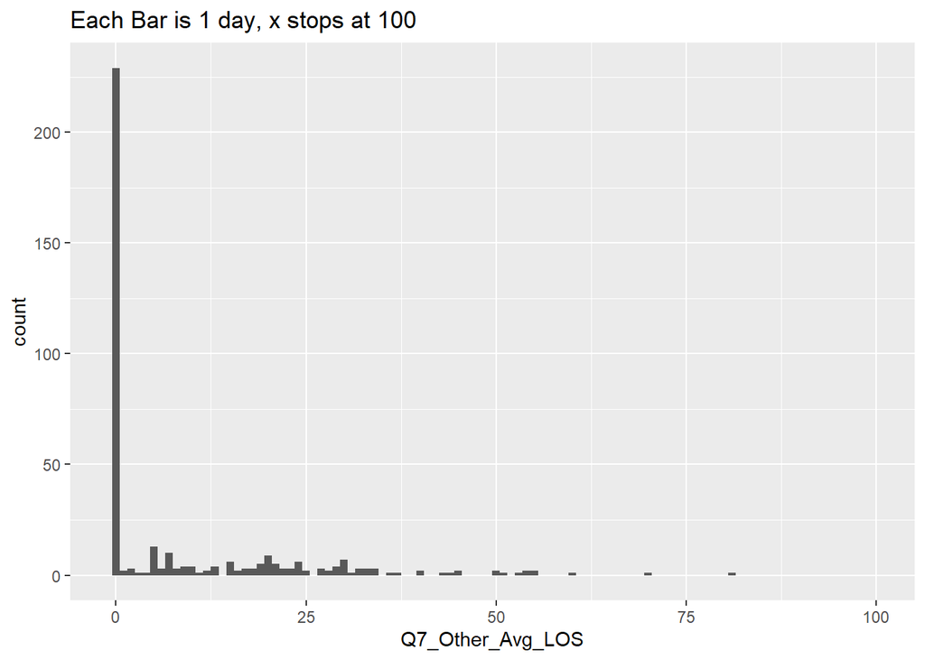

#### Q9 Current Vet Hours

Only asked to those who answered Yes to having at least one vet on staff

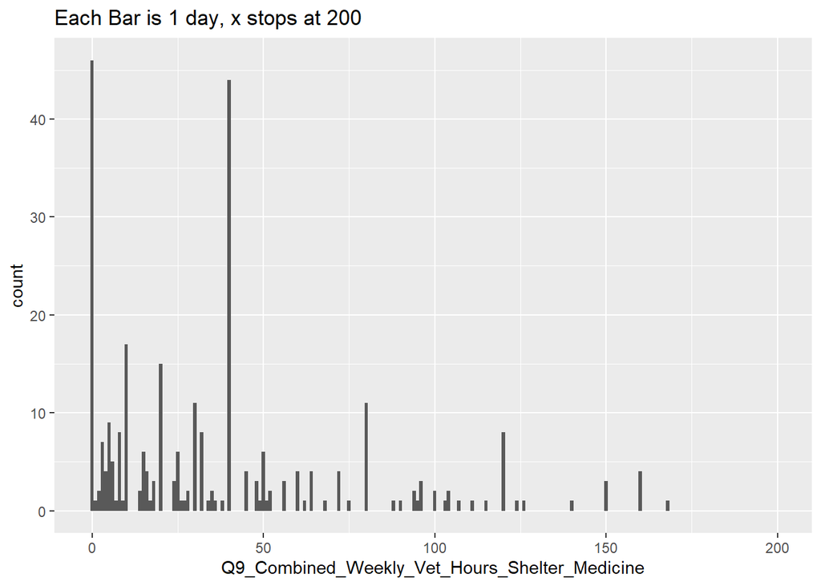

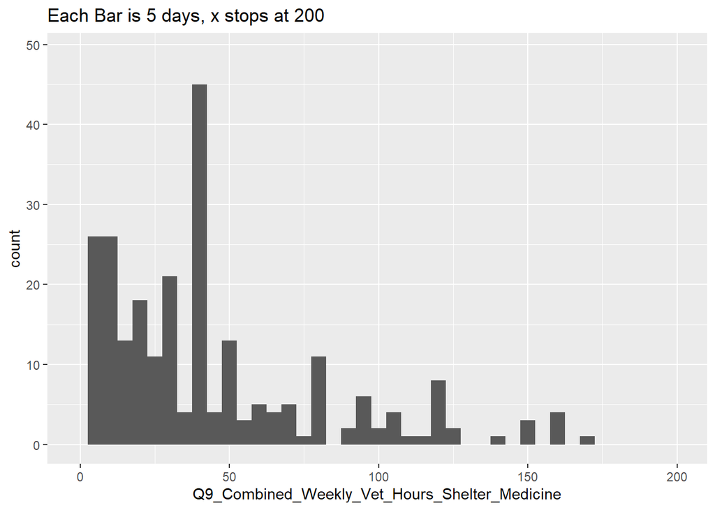

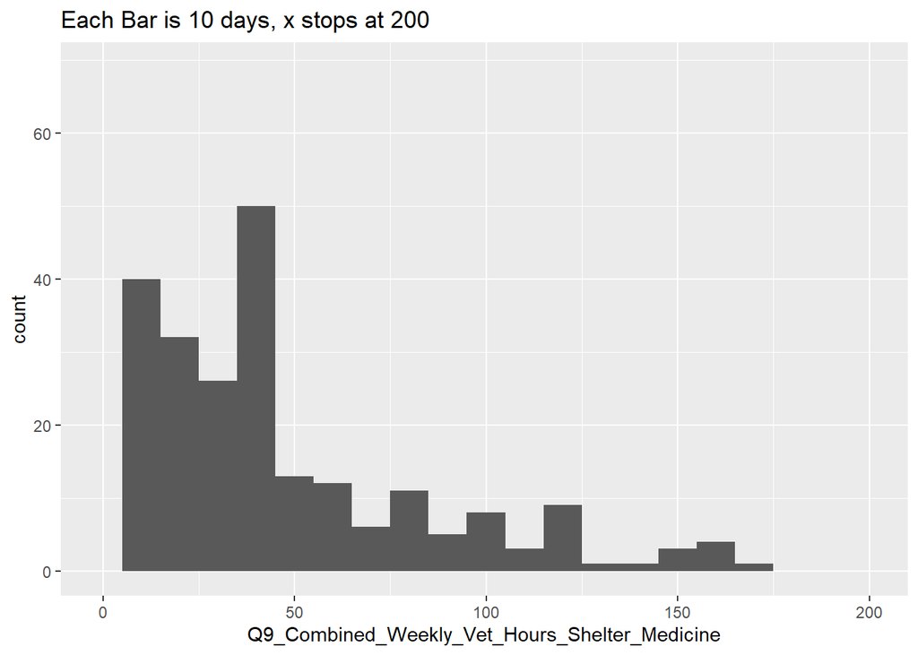

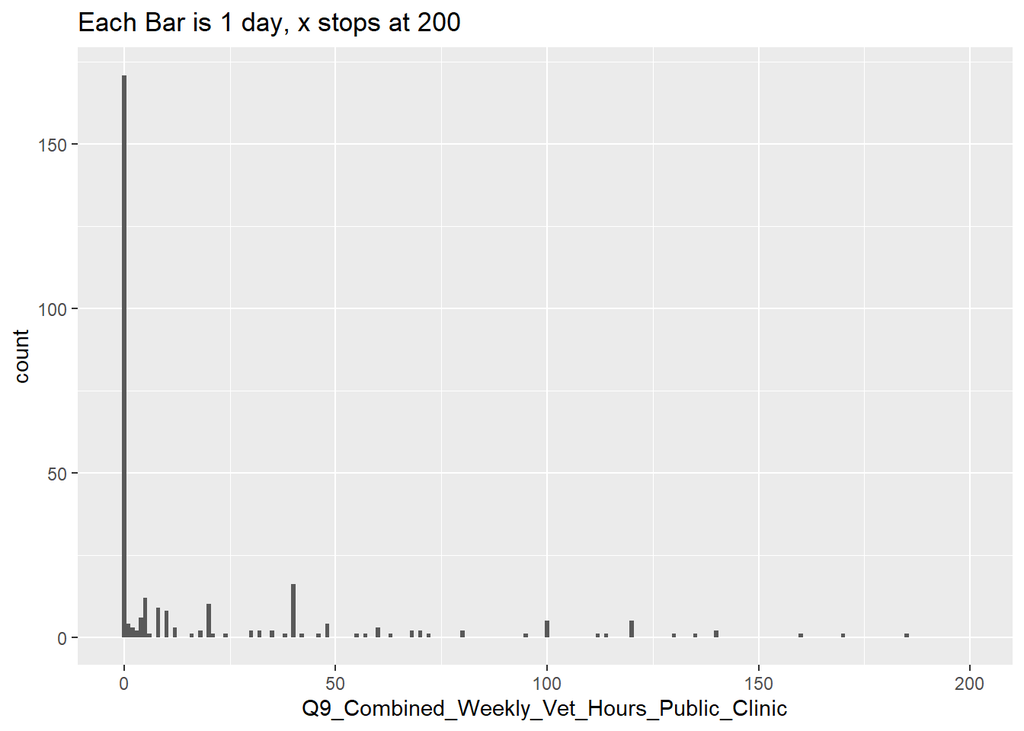

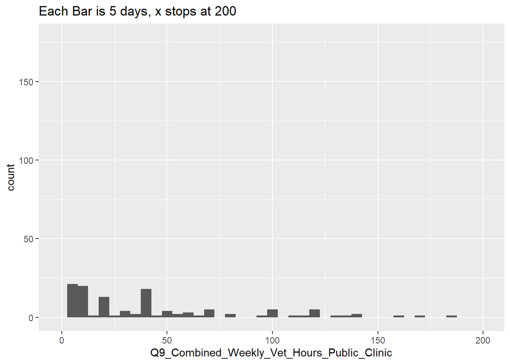

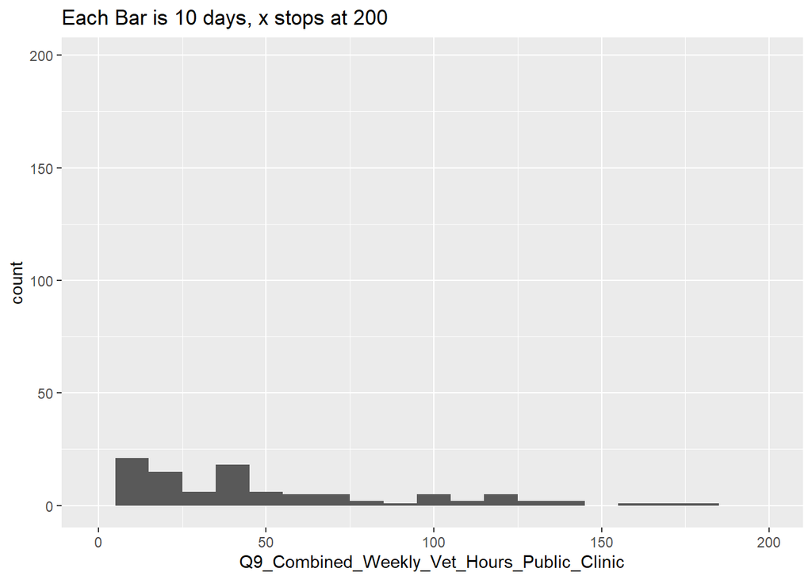

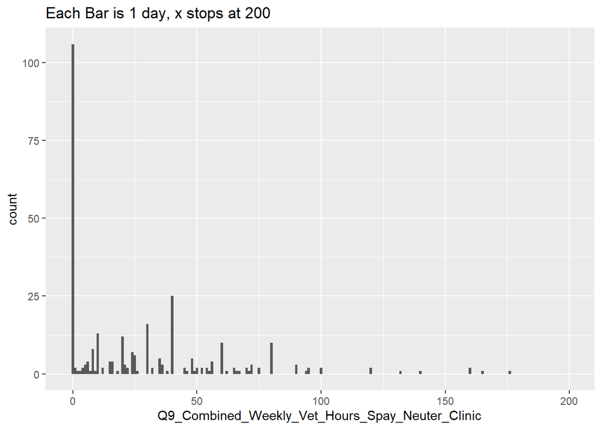

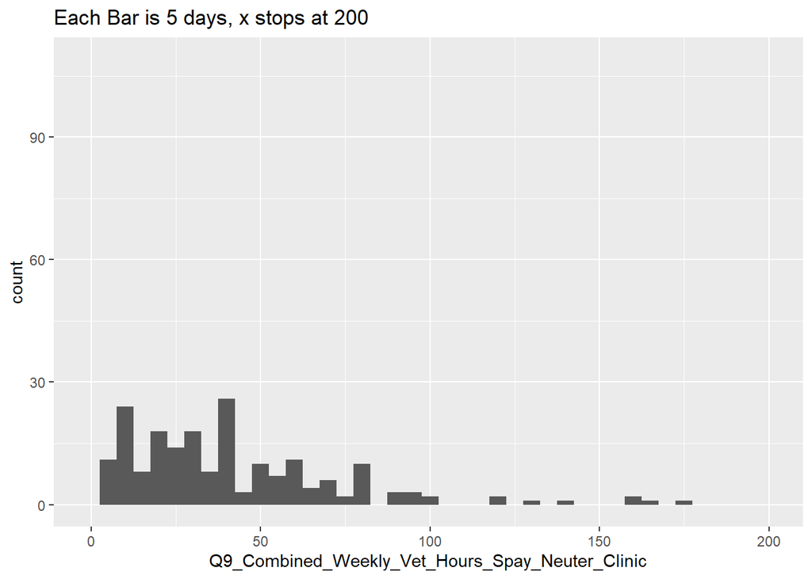

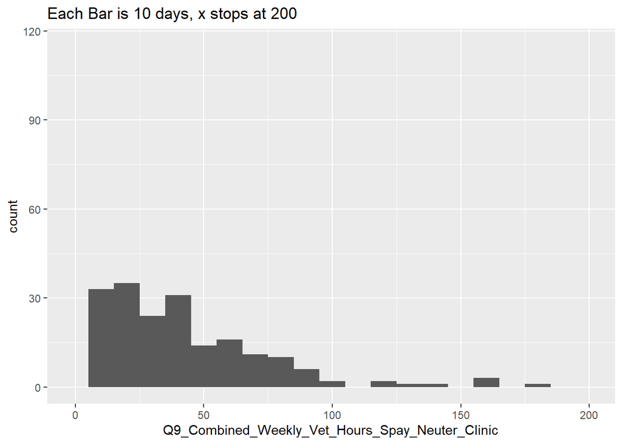

#### Q10 Average Vet Annual Salary

Only asked to those who answered Yes to having at least one vet on staff. There were several people who responded unknown.

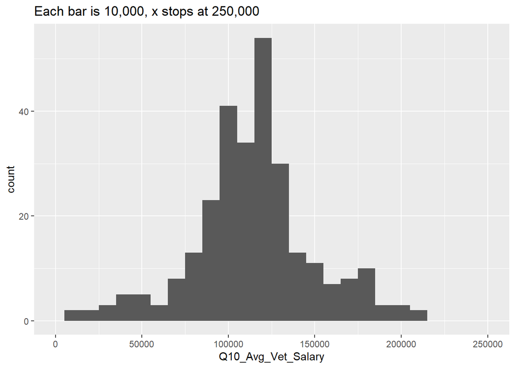

#### Q11 Reasons for Not having a Vet

Only those how responded no to having a vet were asked this question

|  | Q11_No_Vet_Reason_Budget | Count | Percent |
| --- | --- | --- | --- |
| 1 | Yes | 94 | 45.63% |
| 2 |  | 206 |  |

|  | Q11_No_Vet_Reason_Inability_To_Recruit | Count | Percent |
| --- | --- | --- | --- |
| 1 | Yes | 50 | 24.27% |
| 2 |  | 206 |  |

|  | Q11_No_Vet_Reason_Use_Local_Clinic | Count | Percent |
| --- | --- | --- | --- |
| 1 | Yes | 148 | 71.84% |
| 2 |  | 206 |  |

|  | Q11_No_Vet_Reason_Use_Vet_Contractors | Count | Percent |
| --- | --- | --- | --- |
| 1 | Yes | 53 | 25.73% |
| 2 |  | 206 |  |

|  | Q11_No_Vet_Reason_No_Need_For_Vet | Count | Percent |
| --- | --- | --- | --- |
| 1 | Yes | 12 | 5.83% |
| 2 |  | 206 |  |

|  | Q11_No_Vet_Reason_Other | Count | Percent |
| --- | --- | --- | --- |
| 1 | Yes | 38 | 18.45% |
| 2 |  | 206 |  |

#### Q12 Currently Recruiting On-staff Vet

|  | Q12_Org_Recruiting_Vet | Count | Percent |
| --- | --- | --- | --- |
| 1 | No | 352 | 68.75% |
| 2 | Yes | 160 | 31.25% |
| 3 |  | 512 |  |

#### Q13 Vet Care Hours Per Week Looking to Fill

Only those who answered yes to question 12 were asked this question

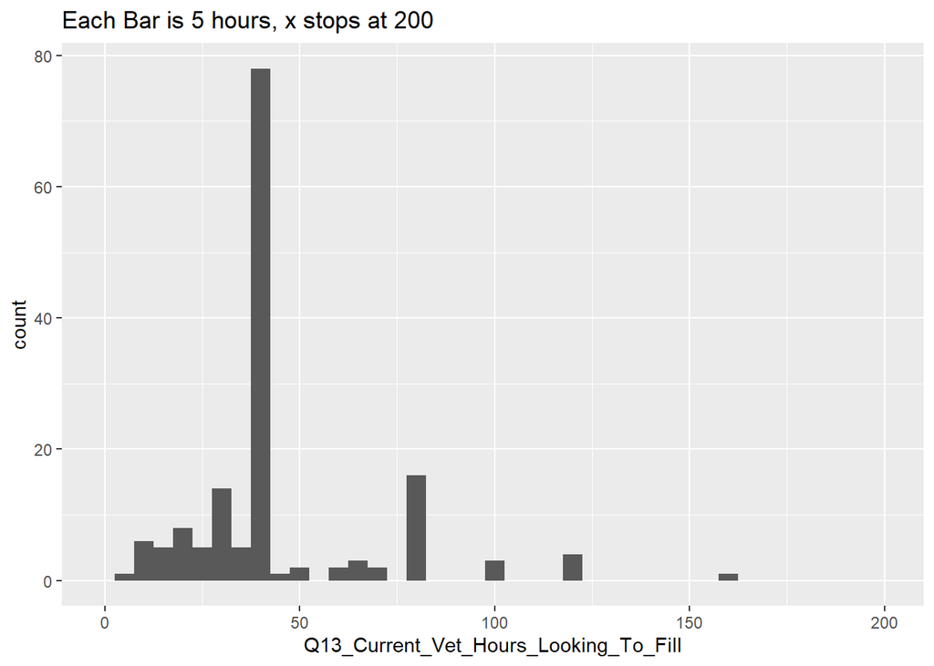

#### Q14 Annual Vet Salary Offered

Only asked those who answered yes to question 12

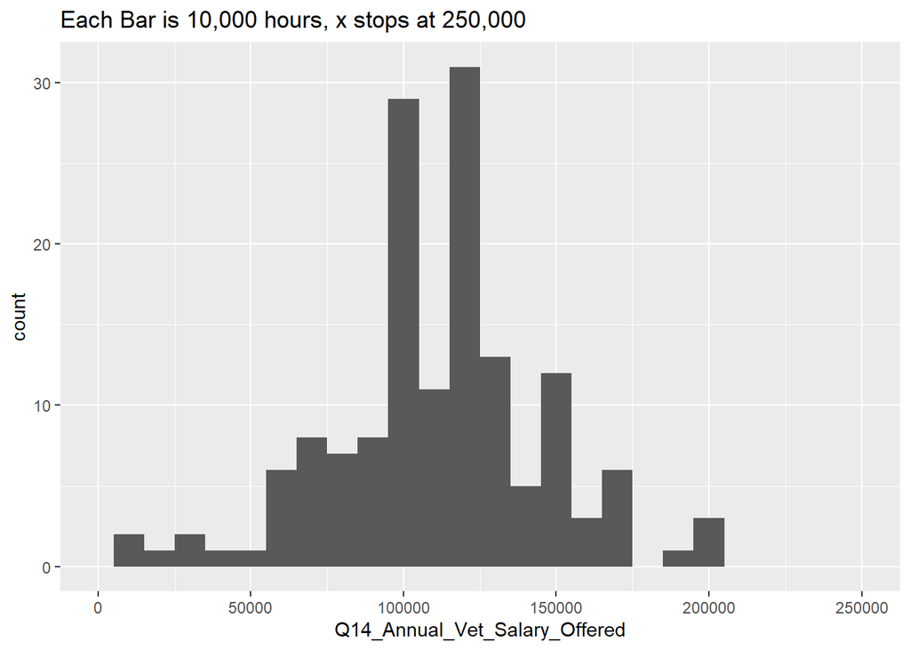

#### Q15 Benefits Currently Offered

Only those who answered yes to question 8 or 12 were asked this question

|  | Q15_Benefits_Annual_Cost_Of_Living_Raise | Count | Percent |
| --- | --- | --- | --- |
| 1 | Yes | 157 | 48.16% |
| 2 |  | 326 |  |

|  | Q15_Benefits_Assigned_Mentor | Count | Percent |
| --- | --- | --- | --- |
| 1 | Yes | 51 | 15.64% |
| 2 |  | 326 |  |

|  | Q15_Benefits_Conference_Attendance_Registration_And_Travel_Expenses | Count | Percent |
| --- | --- | --- | --- |
| 1 | Yes | 221 | 67.79% |
| 2 |  | 326 |  |

|  | Q15_Benefits_Employee_Assistance_Program | Count | Percent |
| --- | --- | --- | --- |
| 1 | Yes | 188 | 57.67% |
| 2 |  | 326 |  |

|  | Q15_Benefits_Flexible_Work_Schedule | Count | Percent |
| --- | --- | --- | --- |
| 1 | Yes | 190 | 58.28% |
| 2 |  | 326 |  |

|  | Q15_Benefits_Health_Insurance | Count | Percent |
| --- | --- | --- | --- |
| 1 | Yes | 248 | 76.07% |
| 2 |  | 326 |  |

|  | Q15_Benefits_Housing_Stipend | Count | Percent |
| --- | --- | --- | --- |
| 1 | Yes | 4 | 1.23% |
| 2 |  | 326 |  |

|  | Q15_Benefits_Merit_Based_Raise | Count | Percent |
| --- | --- | --- | --- |
| 1 | Yes | 144 | 44.17% |
| 2 |  | 326 |  |

|  | Q15_Benefits_Paying_For_Annual_Continuing_Education_Credits | Count | Percent |
| --- | --- | --- | --- |
| 1 | Yes | 236 | 72.39% |
| 2 |  | 326 |  |

|  | Q15_Benefits_Paying_Professional_Association_Dues | Count | Percent |
| --- | --- | --- | --- |
| 1 | Yes | 232 | 71.17% |
| 2 |  | 326 |  |

|  | Q15_Benefits_PTO | Count | Percent |
| --- | --- | --- | --- |
| 1 | Yes | 275 | 84.36% |
| 2 |  | 326 |  |

|  | Q15_Benefits_Relocation_Assistance | Count | Percent |
| --- | --- | --- | --- |
| 1 | Yes | 63 | 19.33% |
| 2 |  | 326 |  |

|  | Q15_Benefits_Retirement_Payments | Count | Percent |
| --- | --- | --- | --- |
| 1 | Yes | 214 | 65.64% |
| 2 |  | 326 |  |

|  | Q15_Benefits_Scheduled_Rotations | Count | Percent |
| --- | --- | --- | --- |
| 1 | Yes | 28 | 8.59% |
| 2 |  | 326 |  |

|  | Q15_Benefits_Signing_Bonus | Count | Percent |
| --- | --- | --- | --- |
| 1 | Yes | 60 | 18.40% |
| 2 |  | 326 |  |

|  | Q15_Benefits_Student_Loan_Repayment | Count | Percent |
| --- | --- | --- | --- |
| 1 | Yes | 45 | 13.80% |
| 2 |  | 326 |  |

|  | Q15_Benefits_Other | Count | Percent |
| --- | --- | --- | --- |
| 1 | Yes | 66 | 20.25% |
| 2 |  | 326 |  |

#### Q16 Factors that Make it Difficult to Recruit Vets

|  | Q16_Stressful_Nature_Work. | Count | Percent |
| --- | --- | --- | --- |
| 1 | Neither | 126 | 24.95% |
| 2 | Somewhat agree | 193 | 38.22% |
| 3 | Somewhat disagree | 34 | 6.73% |
| 4 | Strongly agree | 123 | 24.36% |
| 5 | Strongly disagree | 29 | 5.74% |
| 6 |  | 505 |  |

|  | Q16_Long_Work_Hours | Count | Percent |
| --- | --- | --- | --- |
| 1 | Neither | 170 | 33.66% |
| 2 | Somewhat agree | 118 | 23.37% |
| 3 | Somewhat disagree | 93 | 18.42% |
| 4 | Strongly agree | 43 | 8.51% |
| 5 | Strongly disagree | 81 | 16.04% |
| 6 |  | 505 |  |

|  | Q16_Challenging_Working_Relationships_With_Organization_Leadership | Count | Percent |
| --- | --- | --- | --- |
| 1 | Neither | 171 | 33.86% |
| 2 | Somewhat agree | 72 | 14.26% |
| 3 | Somewhat disagree | 84 | 16.63% |
| 4 | Strongly agree | 31 | 6.14% |
| 5 | Strongly disagree | 147 | 29.11% |
| 6 |  | 505 |  |

|  | Q16_Private_Practice_Offers_Higher_Salary | Count | Percent |
| --- | --- | --- | --- |
| 1 | Neither | 85 | 16.80% |
| 2 | Somewhat agree | 110 | 21.74% |
| 3 | Somewhat disagree | 19 | 3.75% |
| 4 | Strongly agree | 276 | 54.55% |
| 5 | Strongly disagree | 16 | 3.16% |
| 6 |  | 506 |  |

|  | Q16_Lack_of_Training_in_Shelter_Medicine | Count | Percent |
| --- | --- | --- | --- |
| 1 | Neither | 143 | 28.37% |
| 2 | Somewhat agree | 162 | 32.14% |
| 3 | Somewhat disagree | 65 | 12.90% |
| 4 | Strongly agree | 87 | 17.26% |
| 5 | Strongly disagree | 47 | 9.33% |
| 6 |  | 504 |  |

|  | Q16_Geographic_Area_Not_Desirable_For_Residence | Count | Percent |
| --- | --- | --- | --- |
| 1 | Neither | 154 | 30.43% |
| 2 | Somewhat agree | 105 | 20.75% |
| 3 | Somewhat disagree | 76 | 15.02% |
| 4 | Strongly agree | 73 | 14.43% |
| 5 | Strongly disagree | 98 | 19.37% |
| 6 |  | 506 |  |

|  | Q16_No_Flexible_Work_Schedule | Count | Percent |
| --- | --- | --- | --- |
| 1 | Neither | 175 | 34.72% |
| 2 | Somewhat agree | 84 | 16.67% |
| 3 | Somewhat disagree | 92 | 18.25% |
| 4 | Strongly agree | 26 | 5.16% |
| 5 | Strongly disagree | 127 | 25.20% |
| 6 |  | 504 |  |

|  | Q16_Lack_Of_Support_Staff | Count | Percent |
| --- | --- | --- | --- |
| 1 | Neither | 150 | 29.64% |
| 2 | Somewhat agree | 133 | 26.28% |
| 3 | Somewhat disagree | 89 | 17.59% |
| 4 | Strongly agree | 66 | 13.04% |
| 5 | Strongly disagree | 68 | 13.44% |
| 6 |  | 506 |  |

|  | Q16_Lack_Of_Mentorship_From_Senior_Vet | Count | Percent |
| --- | --- | --- | --- |
| 1 | Neither | 221 | 43.94% |
| 2 | Somewhat agree | 111 | 22.07% |
| 3 | Somewhat disagree | 62 | 12.33% |
| 4 | Strongly agree | 33 | 6.56% |
| 5 | Strongly disagree | 76 | 15.11% |
| 6 |  | 503 |  |

|  | Q16_Frustration_Of_Reporting_To_Non-Vet | Count | Percent |
| --- | --- | --- | --- |
| 1 | Neither | 218 | 43.25% |
| 2 | Somewhat agree | 78 | 15.48% |
| 3 | Somewhat disagree | 77 | 15.28% |
| 4 | Strongly agree | 25 | 4.96% |
| 5 | Strongly disagree | 106 | 21.03% |
| 6 |  | 504 |  |

|  | Q16_Mandate_To_Practice_Medicine_Within_Budget_Or_Policy_Constraints | Count | Percent |
| --- | --- | --- | --- |
| 1 | Neither | 157 | 31.03% |
| 2 | Somewhat agree | 151 | 29.84% |
| 3 | Somewhat disagree | 77 | 15.22% |
| 4 | Strongly agree | 43 | 8.50% |
| 5 | Strongly disagree | 78 | 15.42% |
| 6 |  | 506 |  |

|  | Q16_On-Call_After_Hours | Count | Percent |
| --- | --- | --- | --- |
| 1 | Neither | 178 | 35.25% |
| 2 | Somewhat agree | 107 | 21.19% |
| 3 | Somewhat disagree | 63 | 12.48% |
| 4 | Strongly agree | 54 | 10.69% |
| 5 | Strongly disagree | 103 | 20.40% |
| 6 |  | 505 |  |

|  | Q16_Stress_Of_Carrying_The_Professional_Lic_For_The_Org_To_Use_Schedule_II_Narcotics | Count | Percent |
| --- | --- | --- | --- |
| 1 | Neither | 204 | 40.40% |
| 2 | Somewhat agree | 89 | 17.62% |
| 3 | Somewhat disagree | 69 | 13.66% |
| 4 | Strongly agree | 32 | 6.34% |
| 5 | Strongly disagree | 111 | 21.98% |
| 6 |  | 505 |  |

|  | Q16_Burn-Out_And_Compassion_Fatigue | Count | Percent |
| --- | --- | --- | --- |
| 1 | Neither | 133 | 26.23% |
| 2 | Somewhat agree | 187 | 36.88% |
| 3 | Somewhat disagree | 55 | 10.85% |
| 4 | Strongly agree | 110 | 21.70% |
| 5 | Strongly disagree | 22 | 4.34% |
| 6 |  | 507 |  |

|  | Q16_Being_Only_Vet_On_Staff | Count | Percent |
| --- | --- | --- | --- |
| 1 | Neither | 174 | 34.59% |
| 2 | Somewhat agree | 115 | 22.86% |
| 3 | Somewhat disagree | 44 | 8.75% |
| 4 | Strongly agree | 56 | 11.13% |
| 5 | Strongly disagree | 114 | 22.66% |
| 6 |  | 503 |  |

#### Q18 Number of Vet Techs Employed

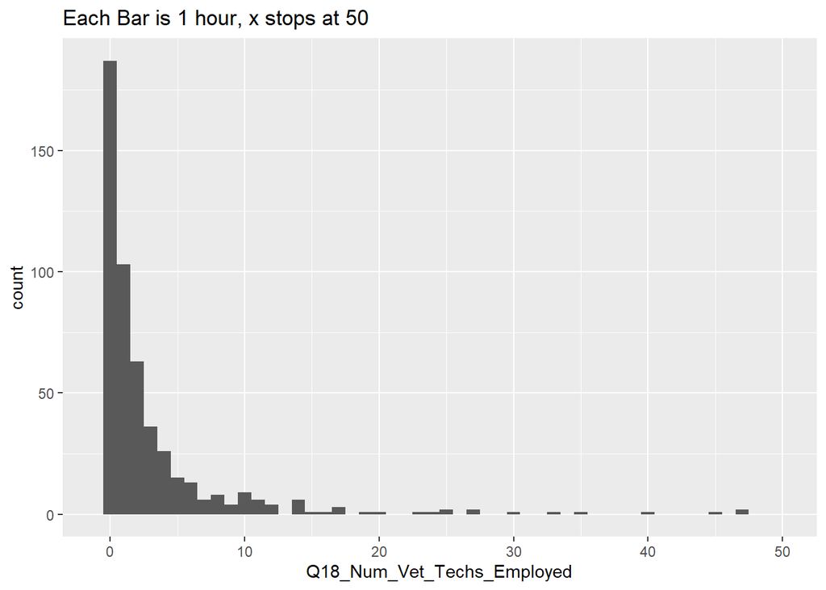

#### Q19 Number of Unlicensed Veterinary Assistants

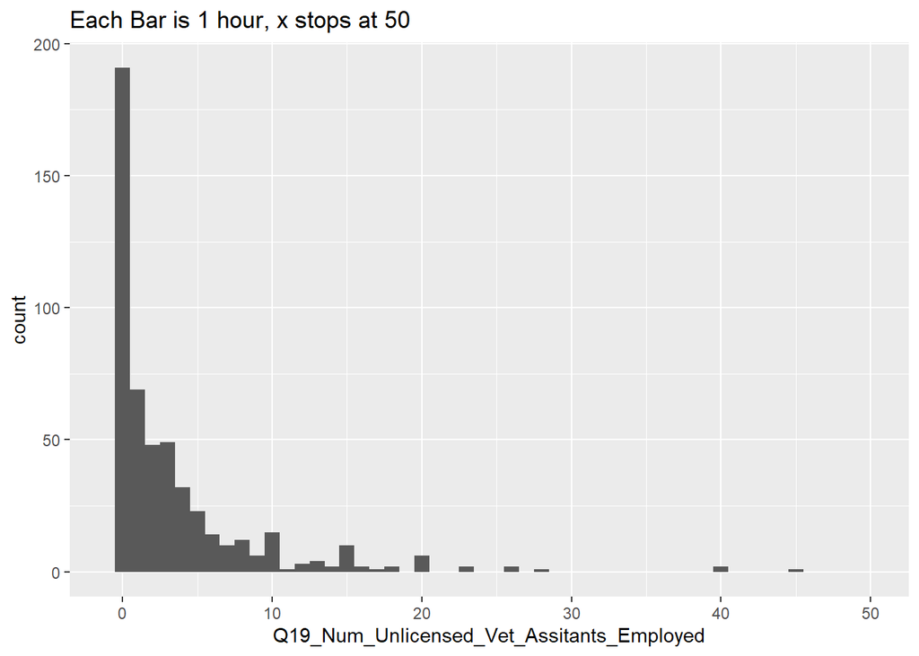

#### Q20 Vet Care Provided

|  | Q20_Provides_Spay-Neuter_For_Org_Animals_By_Own_Vet_Staff_Or_From_A_Local_Vet | Count | Percent |
| --- | --- | --- | --- |
| 1 | Yes | 426 | 84.69% |
| 2 |  | 503 |  |

|  | Q20_Provides_Spay-Neuter_For_Publicly_Owned_Animals | Count | Percent |
| --- | --- | --- | --- |
| 1 | Yes | 287 | 57.06% |
| 2 |  | 503 |  |

|  | Q20_Provides_Owner_Requested_Euthanasia_For_Publicly_Owned_Animals | Count | Percent |
| --- | --- | --- | --- |
| 1 | Yes | 240 | 47.71% |
| 2 |  | 503 |  |

|  | Q20_Provides_Vet_Care_For_Our_Org_Animals | Count | Percent |
| --- | --- | --- | --- |
| 1 | Yes | 440 | 87.48% |
| 2 |  | 503 |  |

|  | Q20_Provides_Non-Spay/Neuter_Vet_Care_For_Publicly_Owned_Animals | Count | Percent |
| --- | --- | --- | --- |
| 1 | Yes | 216 | 42.94% |
| 2 |  | 503 |  |

|  | Q20_Provides_Community_Vaccination_Clinics | Count | Percent |
| --- | --- | --- | --- |
| 1 | Yes | 281 | 55.86% |
| 2 |  | 503 |  |

|  | Q20_Provides_Health_Certificates_For_Transport | Count | Percent |
| --- | --- | --- | --- |
| 1 | Yes | 180 | 35.79% |
| 2 |  | 503 |  |

|  | Q20_Provides_Necropsies_And/Or_Forensic_Work_For_Law_Enforcement | Count | Percent |
| --- | --- | --- | --- |
| 1 | Yes | 128 | 25.45% |
| 2 |  | 503 |  |

|  | Q20_Provides_Specimen_Collection_And_Testing_For_Rabies | Count | Percent |
| --- | --- | --- | --- |
| 1 | Yes | 178 | 35.39% |
| 2 |  | 503 |  |

#### Q34 Access to Vet Care Change Since Pre-Pandemic

|  | Q34_Compared to pre-pandemic access to vet care change | Count | Percent |
| --- | --- | --- | --- |
| 1 | Easier | 31 | 6.08% |
| 2 | More difficult | 267 | 52.35% |
| 3 | No difference | 169 | 33.14% |
| 4 | Not sure | 43 | 8.43% |
| 5 |  | 510 |  |

#### Q35 Vet Workforce Shortage Solutions

|  | Q35_Significant impact to address workforce shortage_Increased utilization of veterinary technicians | Count | Percent |
| --- | --- | --- | --- |
| 1 | Yes | 395 | 78.53% |
| 2 |  | 503 |  |

|  | Q35_Significant impact to address workforce shortage_Creation of midlevel practitioner similar to a physician’s assistant in human medicine | Count | Percent |
| --- | --- | --- | --- |
| 1 | Yes | 378 | 75.15% |
| 2 |  | 503 |  |

|  | Q35_Significant impact to address workforce shortage_Increased scope of practice for existing veterinary technicians without specialist certification | Count | Percent |
| --- | --- | --- | --- |
| 1 | Yes | 296 | 58.85% |
| 2 |  | 503 |  |

|  | Q35_Significant impact to address workforce shortage_Other | Count | Percent |
| --- | --- | --- | --- |
| 1 | Yes | 98 | 19.48% |
| 2 |  | 503 |  |

#### Vet Hours to Animals Ratio

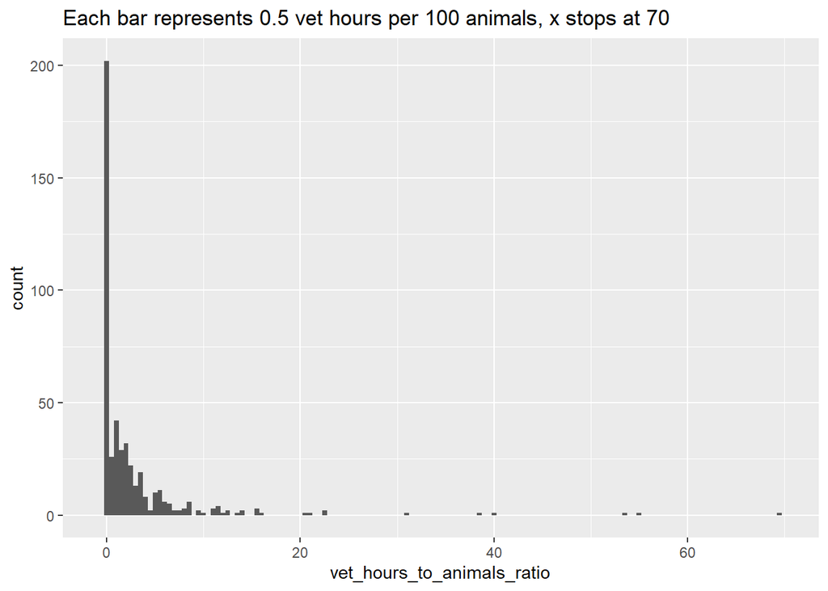

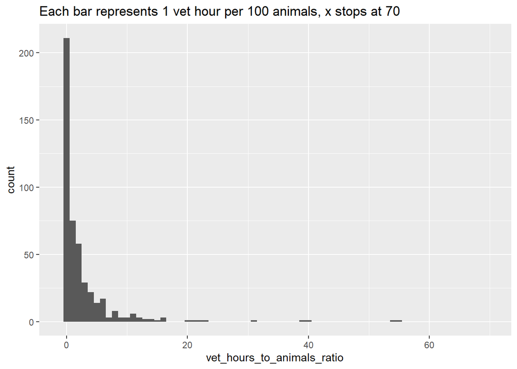

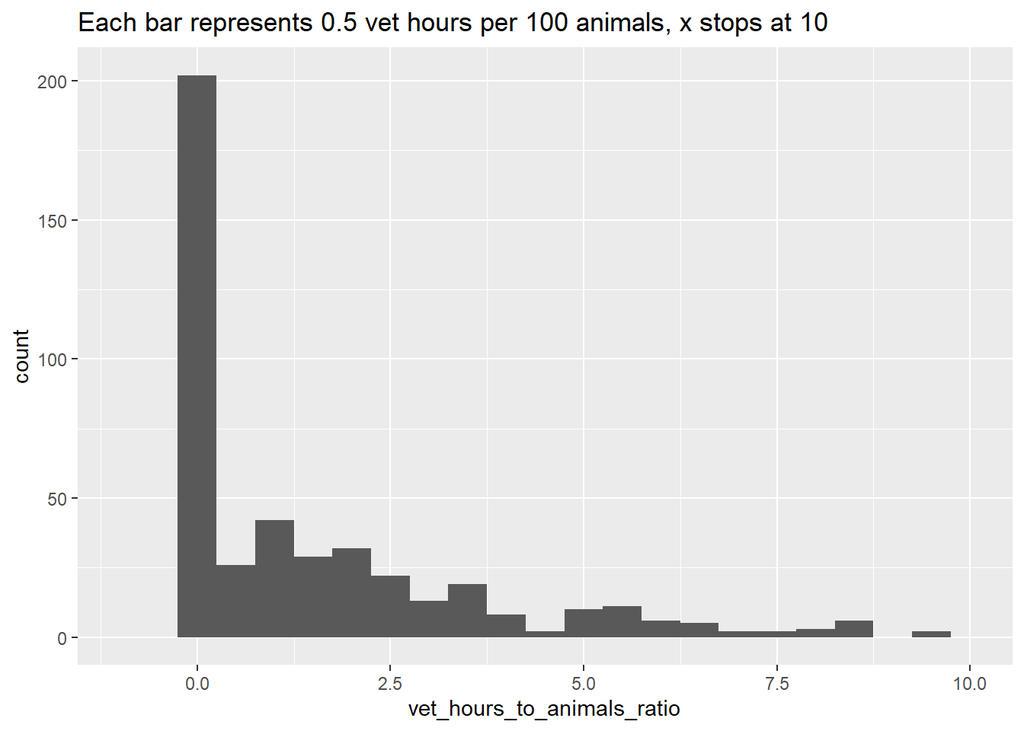

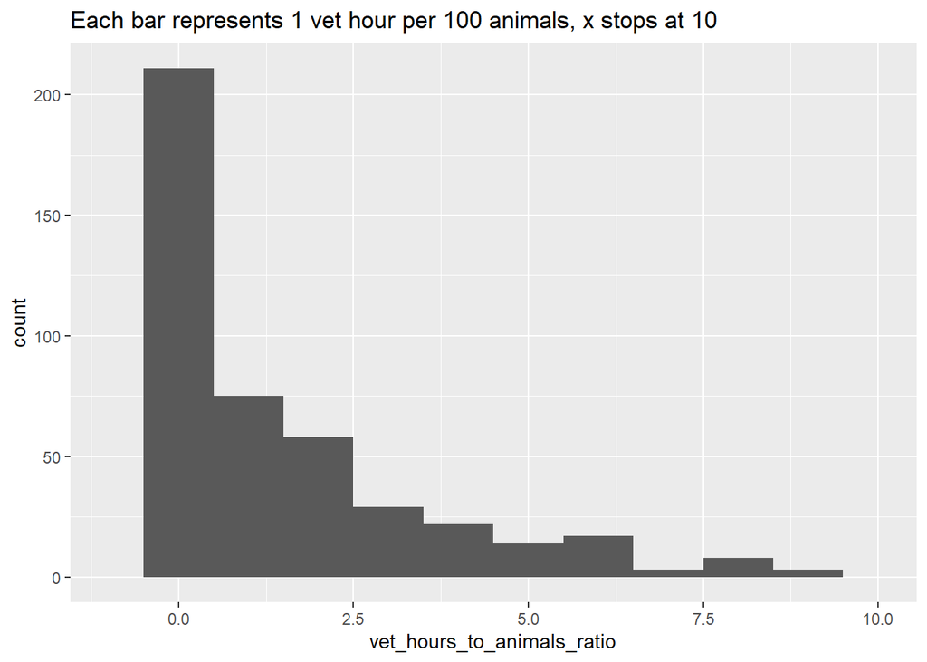

## Org Type

#### Q20 Vet Care Provided

[output not shown]

```
## [1] "Q20_Provides_Spay-Neuter_For_Org_Animals_By_Own_Vet_Staff_Or_From_A_Local_Vet"
```

|  | Q4_Org_Type | Yes | Yes_Pct |
| --- | --- | --- | --- |
| 1 | Brick-and-mortar government animal shelter | 98 | 90.74% |
| 2 | Brick-and-mortar nonprofit animal shelter WITH a government contract for animal control or housing services | 115 | 91.26% |
| 3 | Brick-and-mortar nonprofit animal shelter WITHOUT a government contract for animal control or housing services | 138 | 92.00% |
| 4 | Foster-based animal rescue organization WITH a government contract for animal control and/or sheltering services | 1 | 100.00% |
| 5 | Foster-based animal rescue organization WITHOUT a government contract for animal control and/or sheltering services | 36 | 72.00% |
| 6 | Other | 26 | 66.66% |
| 7 | Spay/neuter clinic | 12 | 41.38% |

```
## [1] "Q20_Provides_Spay-Neuter_For_Publicly_Owned_Animals"
```

|  | Q4_Org_Type | Yes | Yes_Pct |
| --- | --- | --- | --- |
| 1 | Brick-and-mortar government animal shelter | 31 | 28.70% |
| 2 | Brick-and-mortar nonprofit animal shelter WITH a government contract for animal control or housing services | 85 | 67.46% |
| 3 | Brick-and-mortar nonprofit animal shelter WITHOUT a government contract for animal control or housing services | 93 | 62.00% |
| 4 | Foster-based animal rescue organization WITHOUT a government contract for animal control and/or sheltering services | 17 | 34.00% |
| 5 | Other | 32 | 82.06% |
| 6 | Spay/neuter clinic | 29 | 100.00% |

```
## [1] "Q20_Provides_Owner_Requested_Euthanasia_For_Publicly_Owned_Animals"
```

|  | Q4_Org_Type | Yes | Yes_Pct |
| --- | --- | --- | --- |
| 1 | Brick-and-mortar government animal shelter | 72 | 66.66% |
| 2 | Brick-and-mortar nonprofit animal shelter WITH a government contract for animal control or housing services | 85 | 67.46% |
| 3 | Brick-and-mortar nonprofit animal shelter WITHOUT a government contract for animal control or housing services | 54 | 36.00% |
| 4 | Foster-based animal rescue organization WITHOUT a government contract for animal control and/or sheltering services | 2 | 4.00% |
| 5 | Other | 21 | 53.84% |
| 6 | Spay/neuter clinic | 6 | 20.68% |

```
## [1] "Q20_Provides_Vet_Care_For_Our_Org_Animals"
```

|  | Q4_Org_Type | Yes | Yes_Pct |
| --- | --- | --- | --- |
| 1 | Brick-and-mortar government animal shelter | 96 | 88.88% |
| 2 | Brick-and-mortar nonprofit animal shelter WITH a government contract for animal control or housing services | 121 | 96.04% |
| 3 | Brick-and-mortar nonprofit animal shelter WITHOUT a government contract for animal control or housing services | 142 | 94.66% |
| 4 | Foster-based animal rescue organization WITH a government contract for animal control and/or sheltering services | 1 | 100.00% |
| 5 | Foster-based animal rescue organization WITHOUT a government contract for animal control and/or sheltering services | 44 | 88.00% |
| 6 | Other | 27 | 69.24% |
| 7 | Spay/neuter clinic | 9 | 31.04% |

```
## [1] "Q20_Provides_Non-Spay/Neuter_Vet_Care_For_Publicly_Owned_Animals"
```

|  | Q4_Org_Type | Yes | Yes_Pct |
| --- | --- | --- | --- |
| 1 | Brick-and-mortar government animal shelter | 19 | 17.60% |
| 2 | Brick-and-mortar nonprofit animal shelter WITH a government contract for animal control or housing services | 63 | 50.00% |
| 3 | Brick-and-mortar nonprofit animal shelter WITHOUT a government contract for animal control or housing services | 78 | 52.00% |
| 4 | Foster-based animal rescue organization WITH a government contract for animal control and/or sheltering services | 1 | 100.00% |
| 5 | Foster-based animal rescue organization WITHOUT a government contract for animal control and/or sheltering services | 14 | 28.00% |
| 6 | Other | 23 | 58.98% |
| 7 | Spay/neuter clinic | 18 | 62.06% |

```
## [1] "Q20_Provides_Community_Vaccination_Clinics"
```

|  | Q4_Org_Type | Yes | Yes_Pct |
| --- | --- | --- | --- |
| 1 | Brick-and-mortar government animal shelter | 65 | 60.18% |
| 2 | Brick-and-mortar nonprofit animal shelter WITH a government contract for animal control or housing services | 82 | 65.08% |
| 3 | Brick-and-mortar nonprofit animal shelter WITHOUT a government contract for animal control or housing services | 80 | 53.34% |
| 4 | Foster-based animal rescue organization WITH a government contract for animal control and/or sheltering services | 1 | 100.00% |
| 5 | Foster-based animal rescue organization WITHOUT a government contract for animal control and/or sheltering services | 7 | 14.00% |
| 6 | Other | 30 | 76.92% |
| 7 | Spay/neuter clinic | 16 | 55.18% |

```
## [1] "Q20_Provides_Health_Certificates_For_Transport"
```

|  | Q4_Org_Type | Yes | Yes_Pct |
| --- | --- | --- | --- |
| 1 | Brick-and-mortar government animal shelter | 52 | 48.14% |
| 2 | Brick-and-mortar nonprofit animal shelter WITH a government contract for animal control or housing services | 62 | 49.20% |
| 3 | Brick-and-mortar nonprofit animal shelter WITHOUT a government contract for animal control or housing services | 40 | 26.66% |
| 4 | Foster-based animal rescue organization WITHOUT a government contract for animal control and/or sheltering services | 9 | 18.00% |
| 5 | Other | 15 | 38.46% |
| 6 | Spay/neuter clinic | 2 | 6.90% |

```
## [1] "Q20_Provides_Necropsies_And/Or_Forensic_Work_For_Law_Enforcement"
```

|  | Q4_Org_Type | Yes | Yes_Pct |
| --- | --- | --- | --- |
| 1 | Brick-and-mortar government animal shelter | 51 | 47.22% |
| 2 | Brick-and-mortar nonprofit animal shelter WITH a government contract for animal control or housing services | 48 | 38.10% |
| 3 | Brick-and-mortar nonprofit animal shelter WITHOUT a government contract for animal control or housing services | 16 | 10.66% |
| 4 | Foster-based animal rescue organization WITHOUT a government contract for animal control and/or sheltering services | 2 | 4.00% |
| 5 | Other | 11 | 28.20% |

```
## [1] "Q20_Provides_Specimen_Collection_And_Testing_For_Rabies"
```

|  | Q4_Org_Type | Yes | Yes_Pct |
| --- | --- | --- | --- |
| 1 | Brick-and-mortar government animal shelter | 80 | 74.08% |
| 2 | Brick-and-mortar nonprofit animal shelter WITH a government contract for animal control or housing services | 63 | 50.00% |
| 3 | Brick-and-mortar nonprofit animal shelter WITHOUT a government contract for animal control or housing services | 25 | 16.66% |
| 4 | Other | 9 | 23.08% |
| 5 | Spay/neuter clinic | 1 | 3.44% |

## Support Staff Ratio

#### Tables

|  | AAWA_dat$sheltering_region | median | average |
| --- | --- | --- | --- |
| 1 | Atlantic | 1 | 0.8413 |
| 2 | Mid-Northeast | 1 | 0.8087 |
| 3 | Mountain West | 0.875 | 0.7799 |
| 4 | North Central | 1 | 0.7146 |
| 5 | North Midwest | 1 | 0.8443 |
| 6 | Northeast | 0.9342 | 0.7865 |
| 7 | Pacific | 0.8328 | 0.7686 |
| 8 | South Central | 0.6951 | 0.6049 |
| 9 | South Midwest | 1 | 0.7839 |

|  | AAWA_dat$org_intake_size | median | average |
| --- | --- | --- | --- |
| 1 | 2000-5000 | 1 | 0.7864 |
| 2 | 450-2000 | 1 | 0.7547 |
| 3 | Less than 450 | 1 | 0.7999 |
| 4 | More than 5000 | 0.8193 | 0.7698 |

|  | AAWA_dat$Q4_Org_Type | median | average |
| --- | --- | --- | --- |
| 1 | Brick-and-mortar government animal shelter | 1 | 0.744 |
| 2 | Brick-and-mortar nonprofit animal shelter WITH a government contract for animal control or housing services | 0.8469 | 0.764 |
| 3 | Brick-and-mortar nonprofit animal shelter WITHOUT a government contract for animal control or housing services | 1 | 0.8199 |
| 4 | Foster-based animal rescue organization WITH a government contract for animal control and/or sheltering services |  |  |
| 5 | Foster-based animal rescue organization WITHOUT a government contract for animal control and/or sheltering services | 0.6477 | 0.6229 |
| 6 | Other | 0.9545 | 0.7467 |
| 7 | Spay/neuter clinic | 0.7639 | 0.7896 |

#### Histogram

0 are instances where the organization does not currently have vet hours, but they are currently looking to fill vet hours. 1 are instances where the organization does have vet hours, but they are not currently looking to fill any more vet hours. There are 183 instances where an organization does not have vet hours and is not currently looking to fill vet hours.

A high ratio generally means the current vet hours is substantially higher than the vet hours looking to fill. A low ratio generally means the opposite

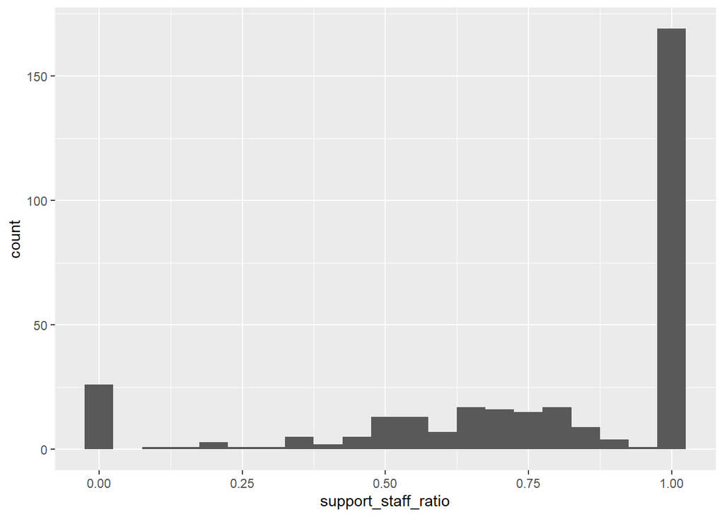